# David - Text Analytics

FACULTY OF COMPUTING AND INFORMATION MANAGEMENT

MSc. DATA ANALYTICS

MDA 5404 – DATA ANALYTICS AND KNOWLEDGE ENGINEERING

ASSIGNMENT II

BY DAVID K. NJUGUNA 19/06596

ASSIGNMENT II SUBMITTED IN PARTIAL FULFILMENT FOR THE REQUIREMENTS FOR THE AWARD OF A DEGREE IN MSc. DATA ANALYTICS

SUBMITTED TO: DR. SIMON MWENDIA

```python
import pandas as pd
import plotly.express as px
import string
import collections
from wordcloud import WordCloud, STOPWORDS, ImageColorGenerator
import matplotlib.cm as cm
import matplotlib.pyplot as plt
import re

stopwords = set(STOPWORDS)
```

### **Loading Data**

We will be exploring a dataset of 50,000 reviews on movies; data from the biggest movie-review database.

Download source from this [link](https://www.kaggle.com/lakshmi25npathi/imdb-dataset-of-50k-movie-reviews?select=IMDB+Dataset.csv)

```python
# pd.set_option('display.max_rows', None)
df = pd.read_csv('./IMDB Dataset.csv')
display(df.count())
display(df.head(5))
display(df.shape)
```

```
review       50000
sentiment    50000
dtype: int64
```

|  | review | sentiment |
| --- | --- | --- |
| 0 | One of the other reviewers has mentioned that ... | positive |
| 1 | A wonderful little production. <br /><br />The... | positive |
| 2 | I thought this was a wonderful way to spend ti... | positive |
| 3 | Basically there's a family where a little boy ... | negative |
| 4 | Petter Mattei's "Love in the Time of Money" is... | positive |

```
(50000, 2)
```

```python
display(df['review'][4])
```

```
'Petter Mattei\'s "Love in the Time of Money" is a visually stunning film to watch. Mr. Mattei offers us a vivid portrait about human relations. This is a movie that seems to be telling us what money, power and success do to people in the different situations we encounter. <br /><br />This being a v…
```

```python
p_r = df[df['sentiment'] == 'positive']['review']
display(p_r.count())
display(p_r.head())

n_r = df[df['sentiment'] == 'negative']['review']
display(n_r.count())
display(n_r.head())
```

```
25000
```

```
0    One of the other reviewers has mentioned that ...
1    A wonderful little production. <br /><br />The...
2    I thought this was a wonderful way to spend ti...
4    Petter Mattei's "Love in the Time of Money" is...
5    Probably my all-time favorite movie, a story o...
Name: review, dtype: object
```

```
25000
```

```
3     Basically there's a family where a little boy ...
7     This show was an amazing, fresh & innovative i...
8     Encouraged by the positive comments about this...
10    Phil the Alien is one of those quirky films wh...
11    I saw this movie when I was about 12 when it c...
Name: review, dtype: object
```

```python
re.sub('[^A-Za-z0-9]+', ' ','\'Petter Mattei\'s "Love in the Time of Money"')
```

```
' Petter Mattei s Love in the Time of Money '
```

### **Pre-processing**

Involves several steps, most of which have been combined in the code sample below:

- Selection - picked the review field only for cleaning and analysis
- Cleaning - removed all special characters, includes expunging html tags
- Transformation - Text is split in separate word arrays
- Integration - performed when performing visualizations

##### **remove all html and special characters**

```python
## convert all to lower case
r_lower = df['review'].str.lower()

## remove all html tags
# r_l_cleaned = list(map(lambda s: re.sub('<[^<]+?>', ' ', s), r_lower))
r_l_cleaned = r_lower.str.replace('<[^<]+?>', ' ')

# remove punctuations
r_l_cleaned = r_l_cleaned.str.replace('[^A-Za-z0-9\s]+', '')

# txt_s = pd.Series(r_l_cleaned.str.sub())
splt_r = r_l_cleaned.str.split(' ')

display(len(splt_r))
display(splt_r[:1])
```

```
50000
```

```
0    [one, of, the, other, reviewers, has, mentione...
Name: review, dtype: object
```

##### **+ve, -ve reviews**

Obtain separate subsets for positive and negative reviews

```python
p_r_lower = p_r.str.lower()
p_r_l_cleaned = p_r_lower.str.replace('<[^<]+?>', ' ')
# remove punctuations
p_r_l_cleaned = p_r_l_cleaned.str.replace('[^A-Za-z0-9\s]+', '')
pr_splt = p_r_l_cleaned.str.split(' ')

display(len(pr_splt))
display(pr_splt[:1])
```

```
25000
```

```
0    [one, of, the, other, reviewers, has, mentione...
Name: review, dtype: object
```

```python
n_r_lower = n_r.str.lower()
n_r_l_cleaned = n_r_lower.str.replace('<[^<]+?>', ' ')
# remove punctuations
n_r_l_cleaned = n_r_l_cleaned.str.replace('[^A-Za-z0-9\s]+', '')
nr_splt = n_r_l_cleaned.str.split(' ')

display(len(nr_splt))
display(nr_splt[:1])
```

```
25000
```

```
3    [basically, theres, a, family, where, a, littl...
Name: review, dtype: object
```

## **Text Analytics**

For Text analysis, I employed two methods which we'll be exploring:

```
- Word Frequency - outputs via a wordcloud visual
- collocation - outputs via a network graph
```

### **Word Frequency**

##### **full dataset**

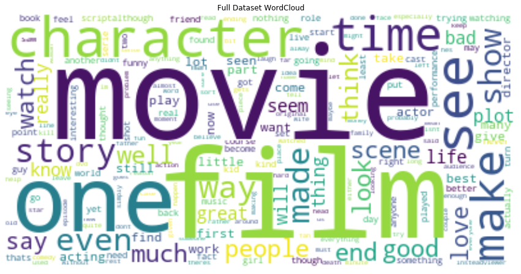

```python
# Integration
t_corpus = [" ".join(t) for t in splt_r]
f_corpus = " ".join(t_corpus)

cloud = WordCloud(background_color='white', stopwords = stopwords).generate(f_corpus)

plt.figure(figsize = (15,15))
plt.imshow(cloud, interpolation = 'bilinear')
plt.title('Full Dataset WordCloud')
plt.axis('off')
plt.show()
```

##### **+ve, -ve review cloud**

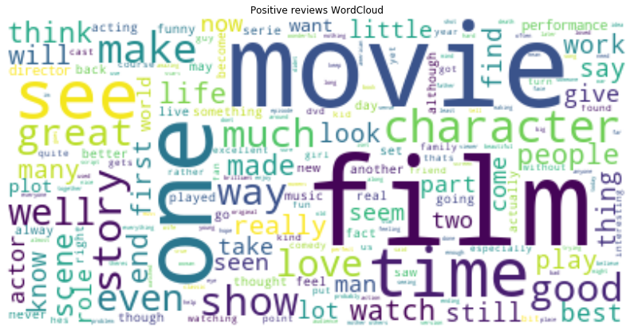

```python
pt_corpus = [" ".join(t) for t in pr_splt]
pf_corpus = " ".join(pt_corpus)

cloud = WordCloud(background_color='white', stopwords = stopwords).generate(pf_corpus)

plt.figure(figsize = (14,14))
plt.imshow(cloud, interpolation = 'bilinear')
plt.title('Positive reviews WordCloud')
plt.axis('off')
plt.show()
```

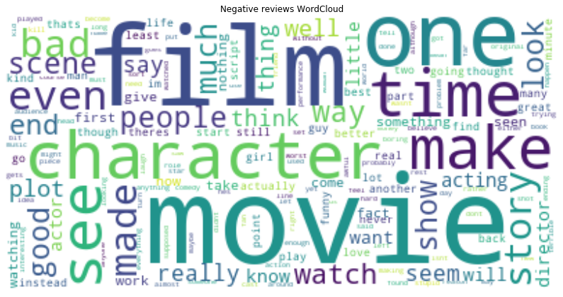

```python
nt_corpus = [" ".join(t) for t in nr_splt]
nf_corpus = " ".join(nt_corpus)

cloud = WordCloud(background_color='white', stopwords = stopwords).generate(nf_corpus)

plt.figure(figsize = (14,14))
plt.imshow(cloud, interpolation = 'bilinear')
plt.title('Negative reviews WordCloud')
plt.axis('off')
plt.show()
```

#### **Interpretations**

*Positive and Negative WordClouds*

```
When observing from the positive wordcloud, positive reviews tend to skew strongly to the positive; tend to be strongly positive i.e. most positive reviews are very positive. Most positive reviews highlighted movie characters, the movie story, a scene

It is interesting when observing from the negative wordcloud. This is because negative reviews are not strongly skewed towards the negative; negative reviews are not strongly negative. This could be due to review curation, which would cull out strongly negative reviews. The size of the words 'bad' and 'good' are similar as per observation. Most negative reviews highlighted movie characters, one item/thing that might have put them off, plot and story. Minor highlights for these reviews were on the director, actor
```

*Full Dataset*

```
The wordcloud for all reviews had reviewers talking about scenes, characters, story, scenes, people, time. Generally Most reviews skew positively, since from the wordcloud the word 'good' seemed to have more occurences than 'bad'. This observation is as expected from a movie review text corpus
```

### **Collocations**

Used Bigrams

```python
# pip install networkx
# pip install nltk
```

```python
from nltk import bigrams
import itertools
import collections
import time
import networkx as nx
```

```python
# add space to remove all spaces
stopwords.add('')
```

```python
st = time.time()

clean_splt_r = [[word for word in review if not word in stopwords] for review in splt_r]

terms_bigram = [list(bigrams(txt)) for txt in clean_splt_r]

et = time.time()

print('elapsed: {:.2f} seconds'.format(et-st))
print(len(terms_bigram))
```

```
elapsed: 4.98 seconds
50000
```

#### **get most common bigrams**

```python
# Flatten list of bigrams in clean tweets
bigrams = list(itertools.chain(*terms_bigram))

# Create counter of words in clean bigrams
bigram_counts = collections.Counter(bigrams)

bigram_counts.most_common(20)
```

```
[(('ive', 'seen'), 3273),
 (('special', 'effects'), 2162),
 (('dont', 'know'), 2087),
 (('even', 'though'), 1939),
 (('one', 'best'), 1869),
 (('waste', 'time'), 1473),
 (('much', 'better'), 1472),
 (('see', 'movie'), 1443),
 (('im', 'sure'), 1392),
 (('first', 'time'), 1344),
 (('good', 'movie'), 1339),
 (('watch', 'movie'), 1290),
 (('new', 'york'), 1263),
 (('dont', 'think'), 1253),
 (('low', 'budget'), 1239),
 (('years', 'ago'), 1235),
 (('movie', 'made'), 1101),
 (('pretty', 'much'), 1097),
 (('pretty', 'good'), 1084),
 (('high', 'school'), 1069)]
```

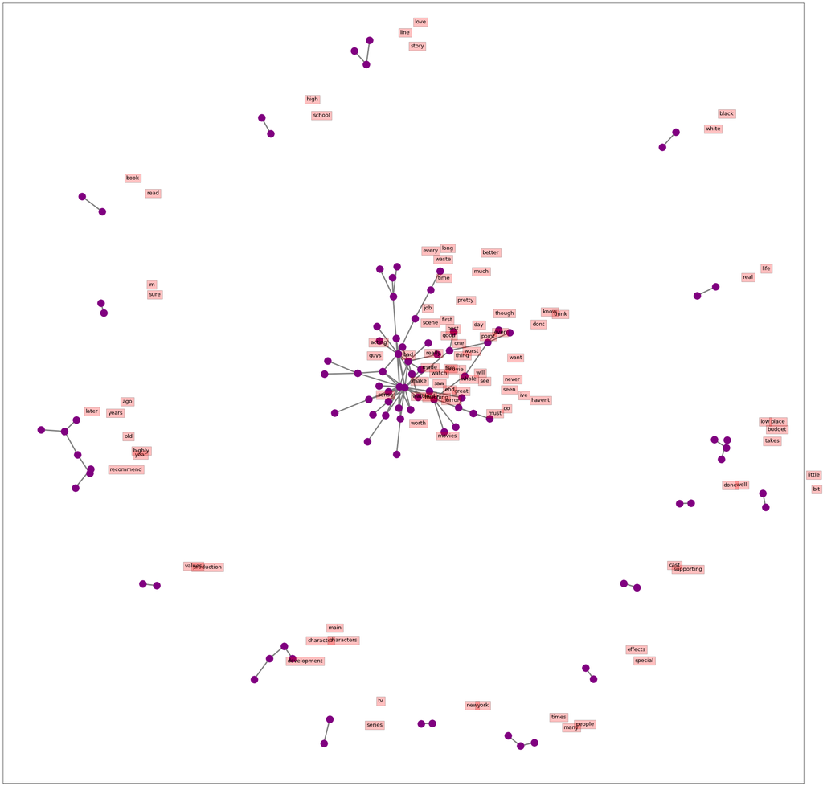

```python
bigram_df = pd.DataFrame(bigram_counts.most_common(100),
                             columns=['bigram', 'count'])

bigram_df

# Create dictionary of bigrams and their counts
d = bigram_df.set_index('bigram').T.to_dict('records')

# Create network plot
G = nx.Graph()

# Create connections between nodes
for k, v in d[0].items():
    G.add_edge(k[0], k[1], weight=(v * 10))

fig, ax = plt.subplots(figsize=(35, 35))

pos = nx.spring_layout(G, k=2)

# Plot networks
nx.draw_networkx(G, pos,
                 font_size=16,
                 width=3,
                 edge_color='grey',
                 node_color='purple',
                 with_labels = False,
                 ax=ax)

# Create offset labels
for key, value in pos.items():
    x, y = value[0]+.135, value[1]+.045
    ax.text(x, y,
            s=key,
            bbox=dict(facecolor='red', alpha=0.25),
            horizontalalignment='center', fontsize=13)

plt.show()
```

#### **Intepretations**

The network graph shows the bigram relations, where a word is represented by a node, and the relationship is represented via an edge (connecting line). More correlated words create a tight cluster between nodes. This means that after observing one of these words in the cluster, there's is a high likelyhood the closely correlated word(s) will also be observed

##### **Discuss potential applications of the extracted patterns**

This extracted patterns can be used for decision making on:

- Getting more reviews on movies based on other locations, or from other locations, to get a more nuanced view on the movies industry
- Pay special attention on special effects, ensuring these are implemented properly
- Pay special attention to the plot/story and movie characters and actors